# Heart-Rate-Variability-Analysis

## Library Imports

```python
import numpy as np
import pandas as pd
from scipy.signal import butter, filtfilt
import matplotlib.pyplot as plt
import seaborn as sns
from scipy.signal import argrelextrema
```

### Helper Functions

```python
# ============ Helper functions ==============

def minmax_normalize(chan: np.ndarray, min_value: int = 0, max_value: int = 1):
    chan = (chan - np.min(chan)) / (np.max(chan) - np.min(chan))
    return chan * (max_value - min_value) + min_value

def derivative_filter(ecg_signal: np.ndarray, fs: int, order: int = 1):
    diff_signal = np.diff(ecg_signal)

    diff_signal = np.concatenate(([0], diff_signal))

    return diff_signal

def lowpass_filter(signal: np.ndarray, cutoff: float, fs: int, order: int = 4):
    nyquist = 0.5 * fs
    normal_cutoff = cutoff / nyquist
    b, a = butter(order, normal_cutoff, btype='low', analog=False)
    filtered_signal = filtfilt(b, a, signal)
    return filtered_signal

def apply_t_wave_suppression(ecg_signal: np.ndarray, fs: int, cutoff: float = 1.0):
    diff_signal = derivative_filter(ecg_signal, fs)

    filtered_signal = lowpass_filter(diff_signal, cutoff, fs)

    return filtered_signal
```

```python
clean_signals = pd.read_csv('data/ecg_ppg_clean.csv')
motion_signals = pd.read_csv('data/ecg_ppg_motion.csv')
```

### 1. Implement a suitable processing before a peak detection. Also, try to create a derivative filter for t-wave suppression. Do the processing for ECG.

##### 1.1. Normalising ECG and it's timestamp

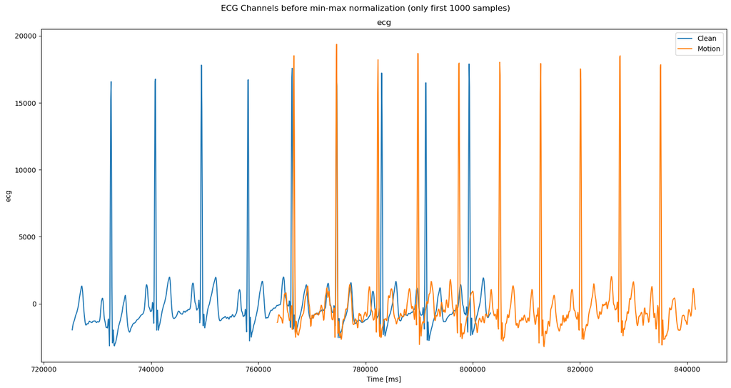

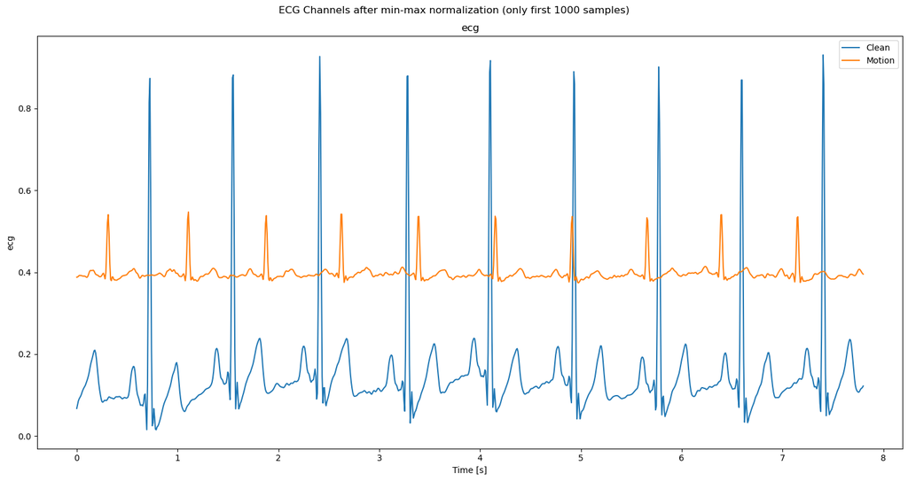

```python
# Since we are doing processing for ECG
sig_cols = ['ecg']
ts_cols = ['timestamps_ecg']

# Normalize and turn the timestamps into seconds first
# Let's not overwrite the original dataframes so take copies
normalized_clean = clean_signals.copy()
normalized_motion = motion_signals.copy()

# Normalize only for timestamps_ecg and ecg
for col in ts_cols + sig_cols:

    # Convert timestamps from milliseconds to seconds
    if 'timestamps' in col:
        normalized_clean[col] = (clean_signals[col] - clean_signals[col].values[0]) / 10000
        normalized_motion[col] = (motion_signals[col] - motion_signals[col].values[0]) / 10000
    else:
        # Normalize the ECG signal
        normalized_clean[col] = minmax_normalize(clean_signals[col].dropna())
        normalized_motion[col] = minmax_normalize(motion_signals[col].dropna())

# Plot channels before normalization
fig, ax = plt.subplots(1, 1, figsize=(15, 8), sharex=True)
fig.suptitle('ECG Channels before min-max normalization (only first 1000 samples)')
sns.lineplot(clean_signals.loc[:1000, :], x=ts_cols[0], y=sig_cols[0], ax=ax, label='Clean').set(title=sig_cols[0], ylabel='', xlabel='Time [ms]')
sns.lineplot(motion_signals.loc[:1000, :], x=ts_cols[0], y=sig_cols[0], ax=ax, label='Motion')

fig.tight_layout()
plt.show()

# Plot channels after normalization
fig, ax = plt.subplots(1, 1, figsize=(15, 8), sharey=True)
fig.suptitle('ECG Channels after min-max normalization (only first 1000 samples)')
sns.lineplot(normalized_clean.loc[:1000, :], x=ts_cols[0], y=sig_cols[0], ax=ax, label='Clean').set(title=sig_cols[0], ylabel='', xlabel='Time [s]')
sns.lineplot(normalized_motion.loc[:1000, :], x=ts_cols[0], y=sig_cols[0], ax=ax, label='Motion')

fig.tight_layout()
plt.show()
```

##### 1.2. Calculating average sample frequency for ECG

```python
avg_sample_freq_ecg = 1 / np.mean(np.diff(normalized_clean['timestamps_ecg']))
print('Average sample frequency for ECG:', avg_sample_freq_ecg)
```

```
Average sample frequency for ECG: 128.2051282051282
```

##### 1.3. Applying the T-wave suppression filter to the ECG signal

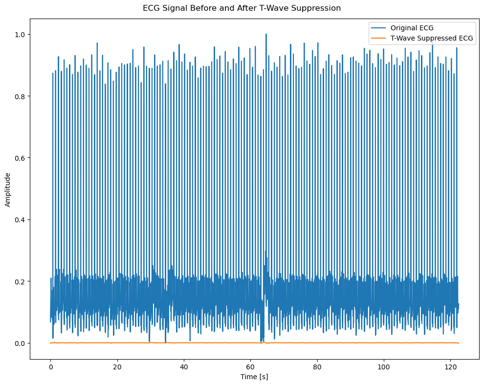

```python
fs = avg_sample_freq_ecg  # Sample frequency in Hz

ecg_signal = normalized_clean['ecg'].values
t_wave_suppressed_signal = apply_t_wave_suppression(ecg_signal, fs)

fig, ax = plt.subplots(1, 1, figsize=(10, 8), sharex=True)
fig.suptitle('ECG Signal Before and After T-Wave Suppression')
ax.plot(normalized_clean['timestamps_ecg'], ecg_signal, label='Original ECG')
ax.plot(normalized_clean['timestamps_ecg'], t_wave_suppressed_signal, label='T-Wave Suppressed ECG')
ax.set_xlabel('Time [s]')
ax.set_ylabel('Amplitude')
ax.legend()
fig.tight_layout()
plt.show()
```

#### 2. Create peak detection algorithm based on finding local maximums. (it does not have to be complicated and you do not need to create one specifically for ppg and for ecg).

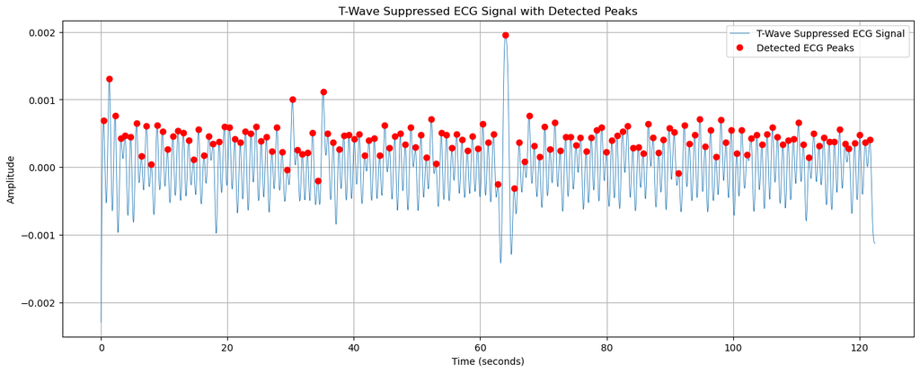

```python
ecg_peaks_indices = argrelextrema(t_wave_suppressed_signal, np.greater)[0]
ecg_peak_values = t_wave_suppressed_signal[ecg_peaks_indices]
ecg_peak_times = normalized_clean['timestamps_ecg'].iloc[ecg_peaks_indices]

plt.figure(figsize=(16, 6))
plt.plot(normalized_clean['timestamps_ecg'], t_wave_suppressed_signal, linewidth=0.6, label="T-Wave Suppressed ECG Signal")
plt.plot(ecg_peak_times, ecg_peak_values, 'ro', label="Detected ECG Peaks")
plt.title("T-Wave Suppressed ECG Signal with Detected Peaks")
plt.xlabel("Time (seconds)")
plt.ylabel("Amplitude")
plt.grid(True)
plt.legend()
plt.show()
```

#### 3. Compute heart rate and remove beat locations that are physiologically impossible based on beat interval.

##### 3.1. Identifying long and short RR intervals

```
Short RR Intervals (< 0.6s): [0.5928]
Long RR Intervals (> 1.2s): [1.209  1.3572]
```

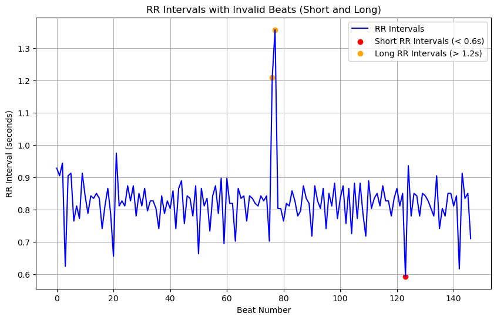

```python
ecg_RR_intervals = np.diff(ecg_peak_times)

short_rr_intervals = ecg_RR_intervals[ecg_RR_intervals < 0.6]
long_rr_intervals = ecg_RR_intervals[ecg_RR_intervals > 1.2]

print("Short RR Intervals (< 0.6s):", short_rr_intervals)
print("Long RR Intervals (> 1.2s):", long_rr_intervals)

plt.figure(figsize=(10, 6))
plt.plot(ecg_RR_intervals, label="RR Intervals", color='blue')
plt.scatter(np.where(ecg_RR_intervals < 0.6), short_rr_intervals, color='red', label="Short RR Intervals (< 0.6s)")
plt.scatter(np.where(ecg_RR_intervals > 1.2), long_rr_intervals, color='orange', label="Long RR Intervals (> 1.2s)")

plt.title("RR Intervals with Invalid Beats (Short and Long)")
plt.xlabel("Beat Number")
plt.ylabel("RR Interval (seconds)")
plt.legend()
plt.grid(True)
plt.show()
```

The RR interval for a healthy adult typically ranges from about 0.6 to 1.2 seconds. A very short RR interval (less than 0.6 seconds) could indicate a high heart rate. A very long RR interval (greater than 1.2 seconds) could indicate a very slow heart rate.

References:  
https://emedicine.medscape.com/article/2172196-overview?form=fpf  
https://www.researchgate.net/figure/The-interval-between-an-R-wave-and-the-next-R-wave-normal-resting-heart-rate-is-between_fig4_361161816

##### 3.2. Removing invalid i.e. short and long RR intervals that aren't physiologically possible

```python
valid_rr_intervals = ecg_RR_intervals[(ecg_RR_intervals >= 0.6) & (ecg_RR_intervals <= 1.2)]

avg_valid_RR_interval = np.mean(valid_rr_intervals)

valid_heart_rate = 60.0 / avg_valid_RR_interval

print(f"ECG - Average RR Interval (Valid Beats): {avg_valid_RR_interval:.4f} seconds")
print(f"ECG - Heart Rate (Valid Beats): {valid_heart_rate:.2f} BPM")
```

```
ECG - Average RR Interval (Valid Beats): 0.8200 seconds
ECG - Heart Rate (Valid Beats): 73.17 BPM
```

#### 4. Estimate heart rate variability using Pointcare and Lorentz plots.

##### References:

https://stackoverflow.com/questions/70301658/drawing-poincare-section-using-python  
https://zhiyzuo.github.io/Plot-Lorenz/

##### 4.1. Pointcare Plot

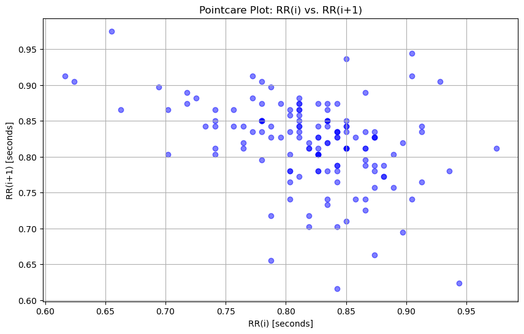

```python
plt.figure(figsize=(10, 6))
plt.scatter(valid_rr_intervals[:-1], valid_rr_intervals[1:], alpha=0.5, color='blue')
plt.title('Pointcare Plot: RR(i) vs. RR(i+1)')
plt.xlabel('RR(i) [seconds]')
plt.ylabel('RR(i+1) [seconds]')
plt.grid(True)
plt.show()
```

The Pointcare plot shows the relationship between one heartbeat interval (RR(i)) and the next (RR(i+1)). It helps visualize how consistent or variable the heart rate is. A tight cluster along the diagonal means the heart rate is stable, while a spread of points indicates higher variability, which is a sign of good heart health.

##### 4.2. Lorentz Plot

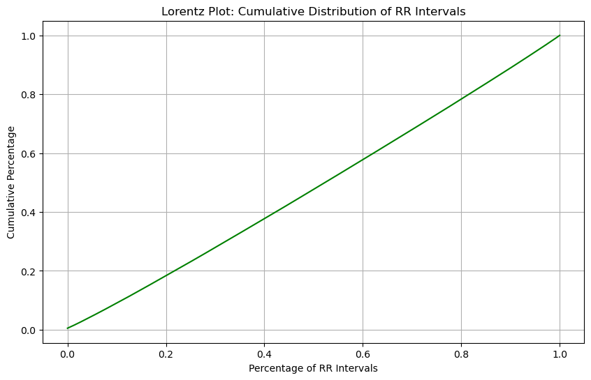

```python
sorted_rr_intervals = np.sort(valid_rr_intervals)
cumulative_rr_intervals = np.cumsum(sorted_rr_intervals) / np.sum(sorted_rr_intervals)

plt.figure(figsize=(10, 6))
plt.plot(np.linspace(0, 1, len(cumulative_rr_intervals)), cumulative_rr_intervals, color='green')
plt.title('Lorentz Plot: Cumulative Distribution of RR Intervals')
plt.xlabel('Percentage of RR Intervals')
plt.ylabel('Cumulative Percentage')
plt.grid(True)
plt.show()
```

The Lorenz plot shows how evenly the time between heartbeats (RR intervals) is distributed. A straight diagonal line means the intervals are uniform, while deviations from this line indicate irregularities in the heart rate.

```python
subset_clean = normalized_clean[:1000]
subset_motion = normalized_motion[:1000]
```

##### 5.1. ECG Peak Detection

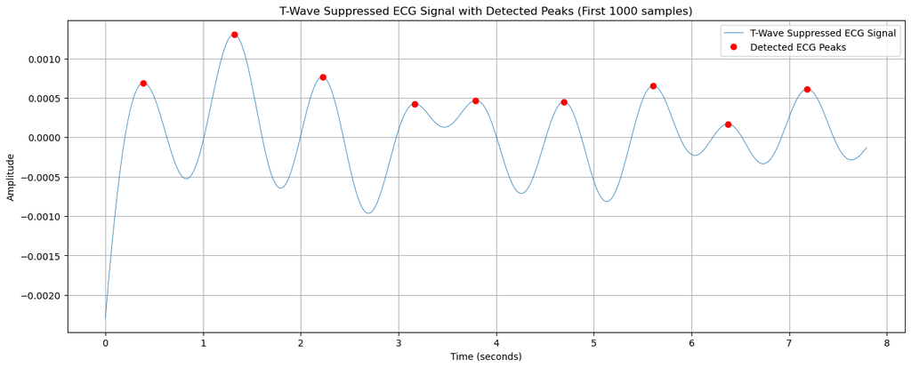

```python
ecg_peaks_indices = argrelextrema(t_wave_suppressed_signal[:1000], np.greater)[0]
ecg_peak_values = t_wave_suppressed_signal[:1000][ecg_peaks_indices]
ecg_peak_times = subset_clean['timestamps_ecg'].iloc[ecg_peaks_indices]  # Using the actual timestamps

plt.figure(figsize=(16, 6))
plt.plot(subset_clean['timestamps_ecg'], t_wave_suppressed_signal[:1000], linewidth=0.6, label="T-Wave Suppressed ECG Signal")
plt.plot(ecg_peak_times, ecg_peak_values, 'ro', label="Detected ECG Peaks")
plt.title("T-Wave Suppressed ECG Signal with Detected Peaks (First 1000 samples)")
plt.xlabel("Time (seconds)")
plt.ylabel("Amplitude")
plt.grid(True)
plt.legend()
plt.show()
```

##### 5.2. Foot Peaks Detection for PPG

[figure not shown]

```python
ppg_peaks_indices = argrelextrema(subset_clean['ppg_1_green'].values, np.less)[0]
ppg_peak_values = subset_clean['ppg_1_green'].iloc[ppg_peaks_indices]
ppg_peak_times = subset_clean['timestamps_ppg_1_green'].iloc[ppg_peaks_indices]

plt.figure(figsize=(16, 6))
plt.plot(subset_clean['timestamps_ppg_1_green'], subset_clean['ppg_1_green'], label="PPG Signal")
plt.plot(ppg_peak_times, ppg_peak_values, 'go', label="Detected Foot Peaks")
plt.title("PPG Signal with Detected Foot Peaks (First 1000 samples)")
plt.xlabel("Time (seconds)")
plt.ylabel("Amplitude")
plt.legend()
plt.grid(True)
plt.show()
```

##### 5.3. Time delay calculation between ECG R-Peaks and PPG Foot Peaks

[figure not shown]

```python
time_delays = []

for ppg_peak_time in ppg_peak_times:
    closest_ecg_peak_idx = np.argmin(np.abs(ecg_peak_times - ppg_peak_time))

    closest_ecg_peak_time = ecg_peak_times.iloc[closest_ecg_peak_idx]

    time_delay = ppg_peak_time - closest_ecg_peak_time
    time_delays.append(time_delay)

plt.figure(figsize=(16, 6))
plt.plot(ppg_peak_times, time_delays, 'bo-', label="Time Delay (PPG Foot Peak to ECG R-peak)")
plt.title("Time Delay Between PPG Foot Peak and ECG R-peak (First 1000 samples)")
plt.xlabel("PPG Foot Peak Time (seconds)")
plt.ylabel("Time Delay (seconds)")
plt.legend()
plt.grid(True)
plt.show()
```